# projec_2_code_1-18

## Project 2

Marc Hernandez, Tilboon Elberier

```python
# import functions needed for problems 1-18
import numpy as np
import matplotlib.pyplot as plt
import pandas as pd
import seaborn as sns

from sklearn.datasets import fetch_20newsgroups
from sklearn.feature_extraction.text import CountVectorizer
from sklearn.feature_extraction.text import TfidfTransformer
from sklearn.decomposition import TruncatedSVD
from sklearn.decomposition import NMF
from sklearn.cluster import KMeans
from sklearn.metrics.cluster import contingency_matrix, homogeneity_score, v_measure_score, completeness_score, adjusted_rand_score, adjusted_mutual_info_score
from sklearn.cluster import AgglomerativeClustering

from scipy import stats
from scipy.optimize import linear_sum_assignment
import importlib
import plotmat
import hdbscan

import warnings
warnings.filterwarnings("ignore")
```

```python
# Import newsgroup data for TFIDF Transformer
cata = ['comp.graphics', 'comp.os.ms-windows.misc', 'comp.sys.ibm.pc.hardware', 'comp.sys.mac.hardware',
        'rec.autos', 'rec.motorcycles', 'rec.sport.baseball', 'rec.sport.hockey']
newsgroups_train = fetch_20newsgroups(subset='all', categories=cata, shuffle=True, random_state=42)
```

QUESTION 1: Report the dimensions of the TF-IDF matrix you obtain.

```python
# Find the Shape of the
countVectorizer = CountVectorizer(min_df=3, stop_words='english')
tfidf_transformer = TfidfTransformer()
newsgroups_counts = countVectorizer.fit_transform(newsgroups_train.data)
newsgroups_tfidf = tfidf_transformer.fit_transform(newsgroups_counts)
print("ANSWER QUESTION 1: The shape of the TF-IDF matrix is ", newsgroups_tfidf.shape)
```

```
ANSWER QUESTION 1: The shape of the TF-IDF matrix is  (7882, 27768)
```

QUESTION 2: Report the contingency table of your clustering result. You may use the provided plotmat.py to visualize the matrix. Does the contingency matrix have to be square-shaped?

```
Contingency table:
 [[3899    4]
 [2292 1687]]
```

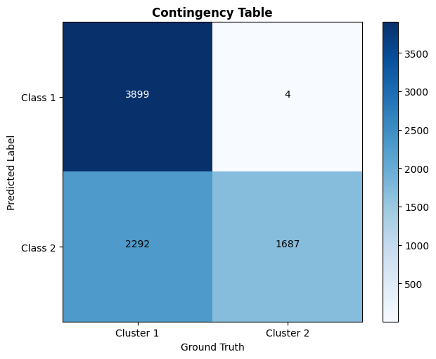

```python
km = KMeans(n_clusters=2, random_state=0, max_iter=1000, n_init=30)
y_pred = km.fit_predict(newsgroups_tfidf)
y_true = [int(i/4) for i in newsgroups_train.target]

cluster_class_names=['Class 1', 'Class 2']
actual_class_names=['Cluster 1', 'Cluster 2']

cm = contingency_matrix(y_true, y_pred)
print("Contingency table: \n", cm)
plt.imshow(cm, cmap=plt.cm.Blues)
plt.colorbar()
plt.xticks(range(len(actual_class_names)), actual_class_names)
plt.yticks(range(len(actual_class_names)), cluster_class_names)


for i in range(cm.shape[0]):
    for j in range(cm.shape[1]):
        if np.argmax(cm) == i*cm.shape[1]+j:
            plt.text(j, i, cm[i, j], horizontalalignment="center", color='w')
        else:
            plt.text(j, i, cm[i, j], horizontalalignment="center", color='k')

plt.tight_layout()
plt.xlabel('Ground Truth')
plt.ylabel('Predicted Label')
plt.title('Contingency Table', fontweight='bold')
plt.show()
```

No, the contingency matrix doesn't have to be square shaped because the matrix itself represents the frequency of occurances between our predictions at the group truth label. The shape of the contringency matrix could be rectangular.

QUESTION 3: Report the 5 clustering measures explained in the introduction for K- means clustering.

```python
print("Below are the 5 clustering Evaluation Metrics described within the project 2 documentation")
def get_metrics(y_true, y_pred):
    diction = {}
    metrics = [homogeneity_score, completeness_score, v_measure_score, adjusted_rand_score, adjusted_mutual_info_score]

    for i in metrics:
        diction[i.__name__] = i(y_true, y_pred)

    df = pd.DataFrame(diction, index=[0]).T
    df.reset_index(inplace=True)
    df.rename(columns={'index':'Evaluation', 0: 'Result'}, inplace=True)

    return df

get_metrics(y_true, y_pred)
```

```
Below are the 5 clustering Evaluation Metrics described within the project 2 documentation
```

|  | Evaluation | Result |
| --- | --- | --- |
| 0 | homogeneity_score | 0.247946 |
| 1 | completeness_score | 0.330542 |
| 2 | v_measure_score | 0.283348 |
| 3 | adjusted_rand_score | 0.174133 |
| 4 | adjusted_mutual_info_score | 0.283273 |

QUESTION 4: Report the plot of the percentage of variance that the top $r$ principle components retain v.s. $r$, for $r = 1$ to $1000$.

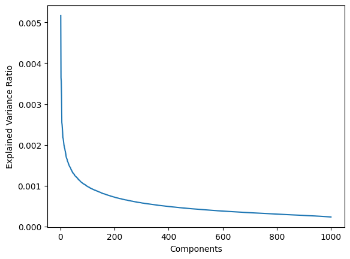

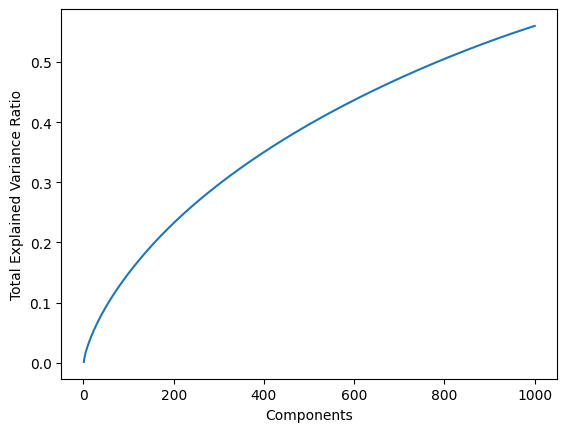

```python
svd = TruncatedSVD(n_components=1000, random_state=42)
X_svd = svd.fit_transform(newsgroups_tfidf)

plt.figure()
plt.plot(np.arange(1000) + 1, sorted(svd.explained_variance_ratio_, reverse=True))
plt.xlabel("Components")
plt.ylabel("Explained Variance Ratio")

plt.figure()
plt.plot(np.arange(1000) + 1, np.cumsum(svd.explained_variance_ratio_))
plt.xlabel("Components")
plt.ylabel("Total Explained Variance Ratio")
```

QUESTION 5: Let r be the dimension that we want to reduce the data to (i.e. n components). Try r = 1 − 10, 20, 50, 100, 300, and plot the 5 measure scores v.s. r for both SVD and NMF.

Report a good choice of r for SVD and NMF respectively.

*Note: In the choice of r, there is a trade-off between the information preservation, and better performance of k-means in lower dimensions.*

```python
components = [1, 2, 3, 4, 5, 6, 7, 8, 9, 10, 20, 50, 100, 300]
km = KMeans(n_clusters=2, random_state=0, max_iter=1000, n_init=30)

result = []
for r in components:
    svd = TruncatedSVD(n_components=r, random_state=42).fit_transform(newsgroups_tfidf)
    preds = km.fit_predict(svd)
    result.append(get_metrics(y_true, preds)['Result'].tolist())

metrics = get_metrics(y_true, preds)['Evaluation'].tolist()
metrics_df = pd.DataFrame(result, columns=metrics, index=components)
metrics_df
```

|  | homogeneity_score | completeness_score | v_measure_score | adjusted_rand_score | adjusted_mutual_info_score |
| --- | --- | --- | --- | --- | --- |
| 1 | 0.000284 | 0.000289 | 0.000286 | 0.000317 | 0.000194 |
| 2 | 0.583085 | 0.585240 | 0.584160 | 0.680448 | 0.584122 |
| 3 | 0.382045 | 0.425804 | 0.402739 | 0.364320 | 0.402682 |
| 4 | 0.230775 | 0.311849 | 0.265255 | 0.161654 | 0.265178 |
| 5 | 0.221171 | 0.309568 | 0.258008 | 0.144576 | 0.257929 |
| 6 | 0.221171 | 0.309568 | 0.258008 | 0.144576 | 0.257929 |
| 7 | 0.226504 | 0.315106 | 0.263557 | 0.148658 | 0.263479 |
| 8 | 0.235158 | 0.321620 | 0.271676 | 0.158405 | 0.271599 |
| 9 | 0.233915 | 0.320684 | 0.270512 | 0.156993 | 0.270434 |
| 10 | 0.234625 | 0.321219 | 0.271177 | 0.157799 | 0.271100 |
| 20 | 0.235514 | 0.321888 | 0.272009 | 0.158809 | 0.271932 |
| 50 | 0.241986 | 0.326035 | 0.277792 | 0.167212 | 0.277716 |
| 100 | 0.242668 | 0.327276 | 0.278692 | 0.167004 | 0.278616 |
| 300 | 0.241949 | 0.326734 | 0.278022 | 0.166176 | 0.277946 |

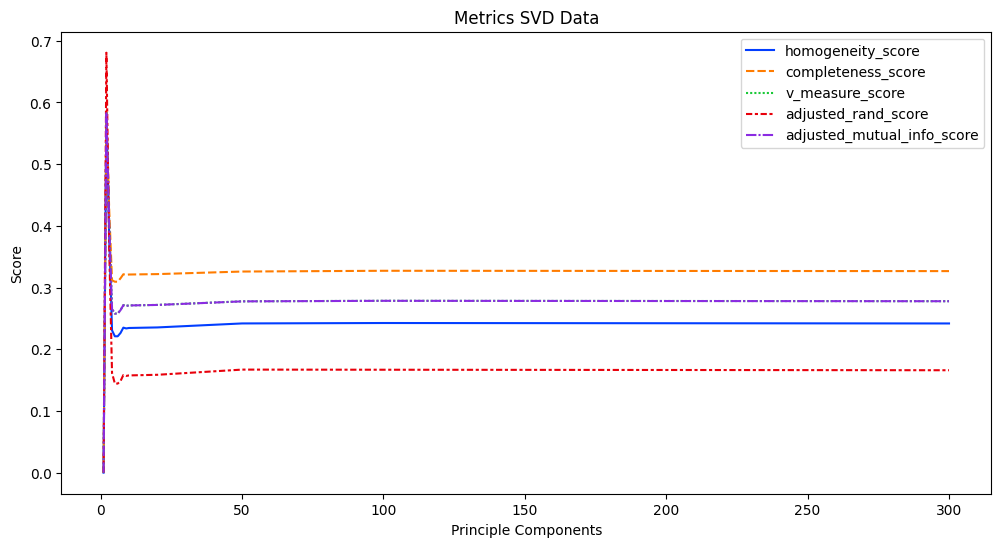

```python
plt.figure(figsize=(12, 6))
sns.set_palette("bright")
g = sns.lineplot(data=metrics_df)
g.set_xlabel('Principle Components')
g.set_ylabel('Score')
g.set_title('Metrics SVD Data')
plt.show()
```

```python
result = []
for r in components:
    nmf = NMF(n_components=r, random_state=42).fit_transform(newsgroups_tfidf)
    preds = km.fit_predict(nmf)
    result.append(get_metrics(y_true, preds)['Result'].tolist())

metrics = get_metrics(y_true, preds)['Evaluation'].tolist()
metrics_df = pd.DataFrame(result, columns=metrics, index=components)
metrics_df
```

[output not shown]

|  | homogeneity_score | completeness_score | v_measure_score | adjusted_rand_score | adjusted_mutual_info_score |
| --- | --- | --- | --- | --- | --- |
| 1 | 0.000284 | 0.000289 | 0.000286 | 0.000317 | 0.000194 |
| 2 | 0.679048 | 0.680132 | 0.679590 | 0.777018 | 0.679560 |
| 3 | 0.229343 | 0.316484 | 0.265957 | 0.152797 | 0.265879 |
| 4 | 0.225779 | 0.310382 | 0.261406 | 0.152996 | 0.261327 |
| 5 | 0.180631 | 0.278709 | 0.219199 | 0.101956 | 0.219112 |
| 6 | 0.185311 | 0.281480 | 0.223489 | 0.107376 | 0.223404 |
| 7 | 0.189325 | 0.286194 | 0.227893 | 0.109886 | 0.227808 |
| 8 | 0.194655 | 0.290243 | 0.233028 | 0.115338 | 0.232943 |
| 9 | 0.185850 | 0.283550 | 0.224533 | 0.106380 | 0.224447 |
| 10 | 0.189823 | 0.286573 | 0.228373 | 0.110392 | 0.228288 |
| 20 | 0.205946 | 0.291986 | 0.241533 | 0.134526 | 0.241451 |
| 50 | 0.001288 | 0.091729 | 0.002540 | 0.000055 | 0.002349 |
| 100 | 0.001288 | 0.091729 | 0.002540 | 0.000055 | 0.002349 |
| 300 | 0.003918 | 0.005839 | 0.004689 | 0.002361 | 0.004580 |

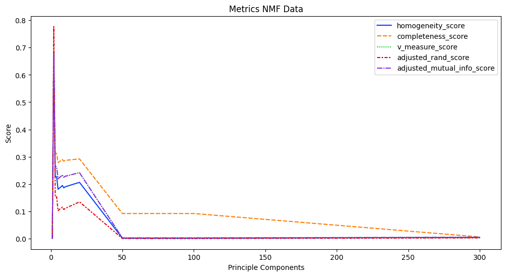

```python
plt.figure(figsize=(12, 6))
sns.set_palette("bright")
g = sns.lineplot(data=metrics_df)
g.set_xlabel('Principle Components')
g.set_ylabel('Score')
g.set_title('Metrics NMF Data')
plt.show()
```

QUESTION 6: How do you explain the non-monotonic behavior of the measures as $r$ increases?

From our graphs we can observe that the influence of the number of components is non-monotonic, as the resulting score does not increase consistently as the number of components also increases. This is likely due to the curse of dimentionality as, K-means relies on the Euclidean Distance to calculate distances between points and nearby clusters, and as we continue to increase the number of cluster groups (i.e. as the number of components increases) then it will be more difficult for our model to properly capture the information provided by the data.

QUESTION 7: Are these measures on average better than those computed in Question 3?

Yes, on average the measurements observed using SVD average do preform better, however, NMF is close and could be argued that it doesn't preform better than the baseline implementation in question 3

QUESTION 8: Visualize the clustering results for:

- SVD with your optimal choice of r for K-Means clustering;
- NMF with your choice of r for K-Means clustering.

To recap, you can accomplish this by first creating the dense representations and then once again projecting these representations into a 2-D plane for visualization.

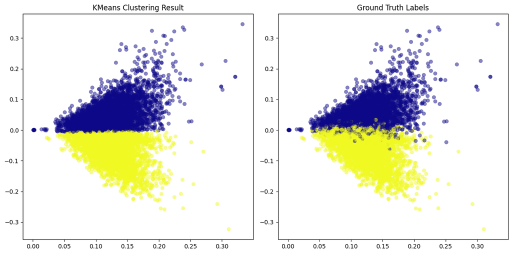

```python
# Best number of components was r = 2
svd = TruncatedSVD(n_components=2, random_state=42).fit_transform(newsgroups_tfidf)
svd_pred = km.fit_predict(svd)

plt.gcf().clear()
plt.figure(figsize=(12,6))
plt.subplot(1,2,1)
plt.scatter(svd[:,0], svd[:,1], c=svd_pred, linewidth=0.5, cmap="plasma", alpha=0.5)
plt.title('KMeans Clustering Result')
plt.subplot(1,2,2)
plt.scatter(svd[:,0], svd[:,1], c=y_true, linewidth=0.5, cmap="plasma", alpha=0.5)
plt.title('Ground Truth Labels')
plt.tight_layout()
plt.show()
```

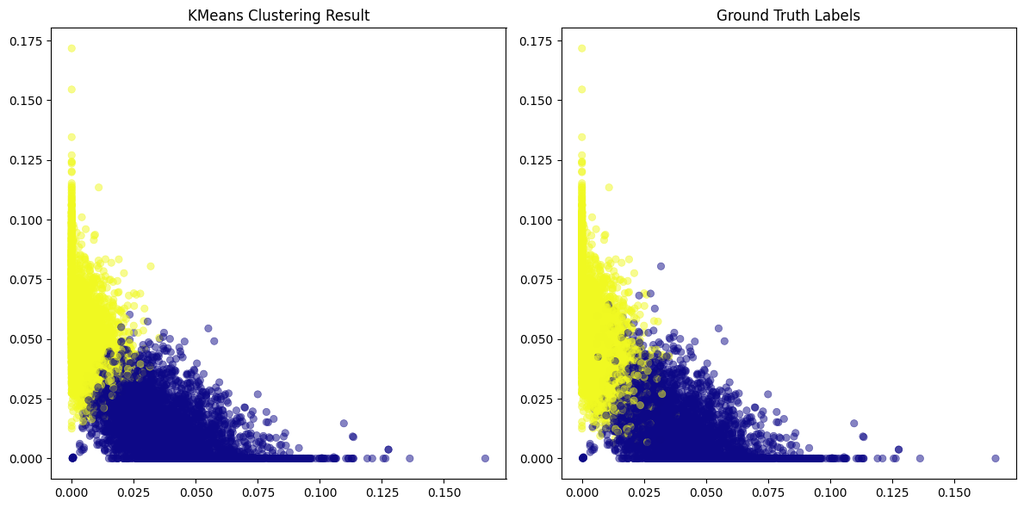

```python
nmf = NMF(n_components=2, random_state=42).fit_transform(newsgroups_tfidf)
nmf_pred = km.fit_predict(nmf)

plt.gcf().clear()
plt.figure(figsize=(12,6))
plt.subplot(1,2,1)
plt.scatter(nmf[:,0], nmf[:,1], c=nmf_pred, cmap="plasma",linewidth=0.5, alpha=0.5)
plt.title('KMeans Clustering Result')
plt.subplot(1,2,2)
plt.scatter(nmf[:,0], nmf[:,1], c=y_true, cmap="plasma", linewidth=0.5, alpha=0.5)
plt.title('Ground Truth Labels')
plt.tight_layout()
plt.show()
```

QUESTION 9: What do you observe in the visualization? How are the data points of the two classes distributed? Is distribution of the data ideal for K-Means clustering?

Based on the plots depicted above, one can say that K-means will likely not be the most optimal model for this dataset. Primarily because of the non-isotropic nature of the formed clusters as well as their frequent overlap in both the SVD and NMF graphs. Because of these two issues, this is not an idea distribution for the use of K-Means clustering.

QUESTION 10: Load documents with the same configuration as in Question 1, but for ALL 20 categories. Construct the TF-IDF matrix, reduce its dimensionality using BOTH NMF and SVD (specify settings you choose and why), and perform K-Means clustering with k=20 . Visualize the contingency matrix and report the five clustering metrics (DO BOTH NMF AND SVD).

There is a mismatch between cluster labels and class labels. For example, the cluster #3 may correspond to the class #8. As a result, the high-value entries of the 20 × 20 contingency matrix can be scattered around, making it messy to inspect, even if the clustering result is not bad.

```python
data_full = fetch_20newsgroups(subset='all', shuffle=True, random_state=42)
```

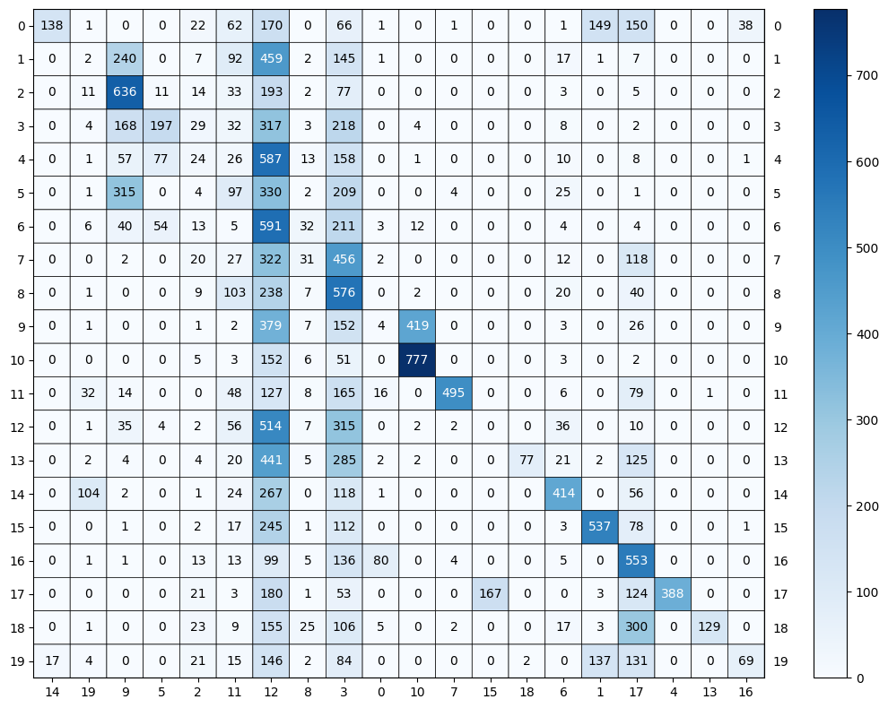

```python
count_full = CountVectorizer(min_df=3, stop_words='english')
tfidf_full = TfidfTransformer()
km = KMeans(n_clusters=20, random_state=0, max_iter=1000, n_init=30)
full_counts = count_full.fit_transform(data_full.data)
tfidf_preds = tfidf_full.fit_transform(full_counts)

svd = TruncatedSVD(n_components=20, random_state=42).fit_transform(tfidf_preds)
svd_pred = km.fit_predict(svd)
cm = contingency_matrix(data_full.target, svd_pred)
rows, cols = linear_sum_assignment(cm, maximize=True)
reordered_mat = cm[np.ix_(rows, cols)]
plotmat.plot_mat(reordered_mat, xticklabels=cols, yticklabels=rows, size=(10,8))
```

```python
get_metrics(data_full.target, y_pred)
```

[output not shown]

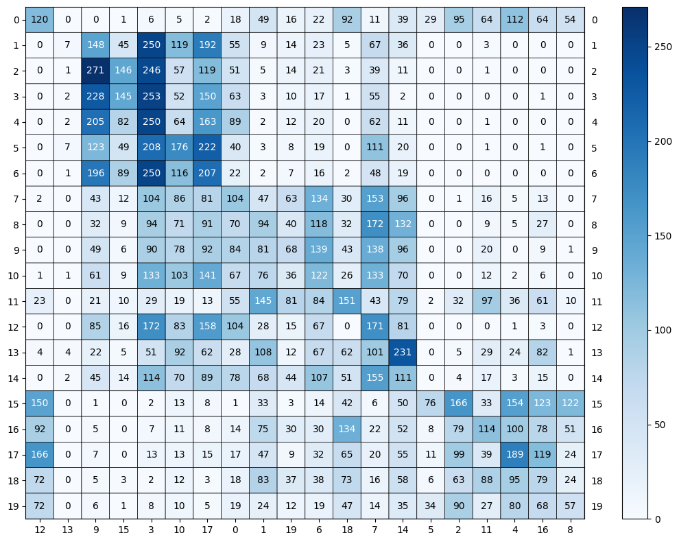

```python
count_full = CountVectorizer(min_df=3, stop_words='english')
tfidf_full = TfidfTransformer()
km = KMeans(n_clusters=20, random_state=0, max_iter=1000, n_init=30)
full_counts = count_full.fit_transform(data_full.data)
tfidf_preds = tfidf_full.fit_transform(full_counts)

nmf = NMF(n_components=2, random_state=42).fit_transform(tfidf_preds)
nmf_pred = km.fit_predict(nmf)
cm = contingency_matrix(data_full.target, nmf_pred)
rows, cols = linear_sum_assignment(cm, maximize=True)
reordered_mat = cm[np.ix_(rows, cols)]
plotmat.plot_mat(reordered_mat, xticklabels=cols, yticklabels=rows, size=(10,8))
```

```python
get_metrics(data_full.target, nmf_pred)
```

|  | Evaluation | Result |
| --- | --- | --- |
| 0 | homogeneity_score | 0.169491 |
| 1 | completeness_score | 0.179924 |
| 2 | v_measure_score | 0.174552 |
| 3 | adjusted_rand_score | 0.051011 |
| 4 | adjusted_mutual_info_score | 0.171780 |

QUESTION 11: Reduce the dimension of your dataset with UMAP. Consider the following settings: n components = [5, 20, 200], metric = ”cosine” vs. ”euclidean”. If ”cosine” metric fails, please look at the FAQ at the end of this spec.

**Report the permuted contingency matrix and the five clustering evaluation metrics for the different combinations (6 combinations).**

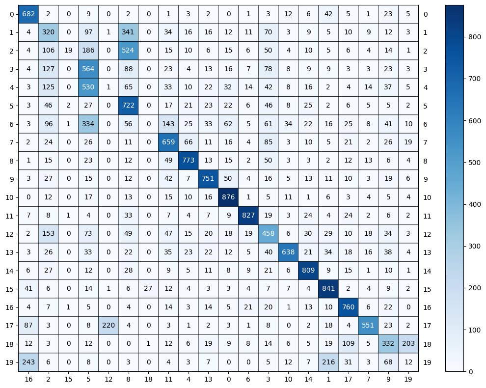

```
Number of Components:  5 Evaluating Metric:  cosine
Homogeneity : 0.494
Completeness : 0.526
V-measure : 0.510
Adjusted Rand-Index : 0.389
Adjusted Mutual Information Score : 0.508
```

[output not shown]

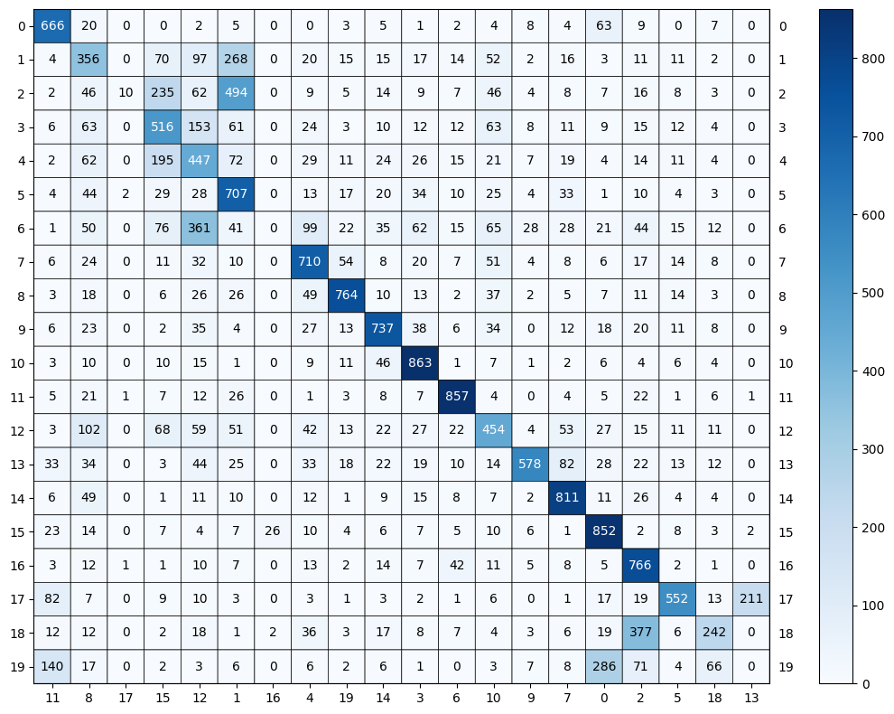

```
Number of Components:  5 Evaluating Metric:  euclidean
Homogeneity : 0.492
Completeness : 0.520
V-measure : 0.506
Adjusted Rand-Index : 0.393
Adjusted Mutual Information Score : 0.504
```

[output not shown]

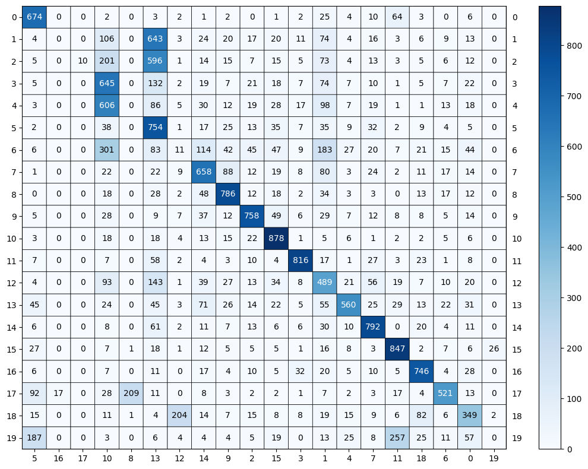

```
Number of Components:  20 Evaluating Metric:  cosine
Homogeneity : 0.482
Completeness : 0.532
V-measure : 0.506
Adjusted Rand-Index : 0.368
Adjusted Mutual Information Score : 0.504
```

[output not shown]

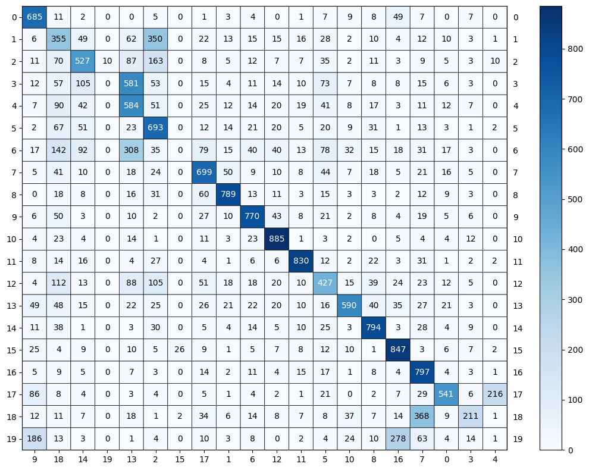

```
Number of Components:  20 Evaluating Metric:  euclidean
Homogeneity : 0.499
Completeness : 0.529
V-measure : 0.514
Adjusted Rand-Index : 0.403
Adjusted Mutual Information Score : 0.512
```

[output not shown]

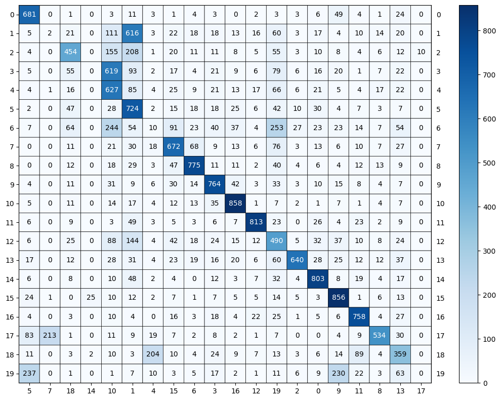

```
Number of Components:  200 Evaluating Metric:  cosine
Homogeneity : 0.501
Completeness : 0.536
V-measure : 0.518
Adjusted Rand-Index : 0.396
Adjusted Mutual Information Score : 0.516
```

[output not shown]

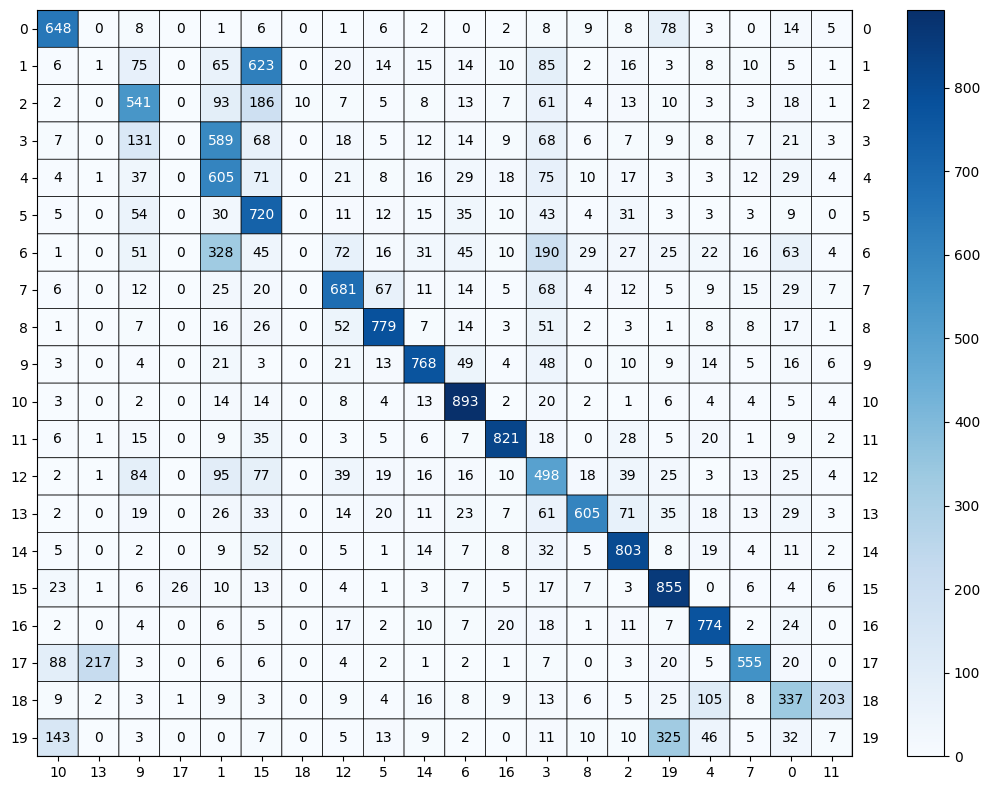

```
Number of Components:  200 Evaluating Metric:  euclidean
Homogeneity : 0.508
Completeness : 0.543
V-measure : 0.525
Adjusted Rand-Index : 0.405
Adjusted Mutual Information Score : 0.523
```

```python
import umap.umap_ as umap

components = [5,20,200]
metric = ["cosine", "euclidean"]

for n in components:
    for i in metric:
        umap_full = umap.UMAP(n_components=n, metric=i).fit_transform(tfidf_preds)
        km = KMeans(n_clusters=20, random_state=0, max_iter=1000, n_init=30)
        y_pred = km.fit_predict(umap_full)

        cm = contingency_matrix(data_full.target, y_pred)
        rows, cols = linear_sum_assignment(cm, maximize=True)
        reordered_mat = cm[np.ix_(rows, cols)]
        plotmat.plot_mat(reordered_mat, xticklabels=cols, yticklabels=rows, size=(10,8))

        print("Number of Components: ", n, "Evaluating Metric: ", i)
        print("Homogeneity : %0.3f" % homogeneity_score(data_full.target, y_pred))
        print("Completeness : %0.3f" % completeness_score(data_full.target, y_pred))
        print("V-measure : %0.3f" % v_measure_score(data_full.target, y_pred))
        print("Adjusted Rand-Index : %.3f"% adjusted_rand_score(data_full.target, y_pred))
        print("Adjusted Mutual Information Score : %.3f"% adjusted_mutual_info_score(data_full.target, y_pred))
```

QUESTION 12: Analyze the contingency matrices. Which setting works best and why? What about for each metric choice?

Based on our evaluations of the 6 combinations, the iteration with a number of components of 200 and the metric of euclidean, was able to achieve the highest scores on all 5 metrics when compared against its counter parts. Indicating that these setting lead to the most optimal combination of hyper parameters for the full newsgroup data.

QUESTION 14: Use UMAP to reduce the dimensionality properly, and perform Agglom- erative clustering with n_clusters=20 . Compare the performance of “ward” and “single” linkage criteria.

**Report the five clustering evaluation metrics for each case.**

```python
umap_full = umap.UMAP(n_components=20, metric='euclidean').fit_transform(tfidf_preds)
agg_cluster = AgglomerativeClustering(n_clusters = 20, linkage = 'ward')
agg_pred = agg_cluster.fit(umap_full)
y_pred = agg_pred.labels_

print("Homogeneity : ", homogeneity_score(data_full.target, y_pred))
print("Completeness : ",  completeness_score(data_full.target, y_pred))
print("V-measure : ",  v_measure_score(data_full.target, y_pred))
print("Adjusted Rand-Index : ", adjusted_rand_score(data_full.target, y_pred))
print("Adjusted Mutual Information Score : ", adjusted_mutual_info_score(data_full.target, y_pred))

umap_full = umap.UMAP(n_components=20, metric='euclidean').fit_transform(tfidf_preds)
agg_cluster = AgglomerativeClustering(n_clusters = 20, linkage = 'single')
y_pred = agg_cluster.fit_predict(umap_full)
# y_pred = agg_pred.labels_

print("Homogeneity : " , homogeneity_score(data_full.target, y_pred))
print("Completeness : " , completeness_score(data_full.target, y_pred))
print("V-measure : " , v_measure_score(data_full.target, y_pred))
print("Adjusted Rand-Index : ", adjusted_rand_score(data_full.target, y_pred))
print("Adjusted Mutual Information Score : ", adjusted_mutual_info_score(data_full.target, y_pred))
```

```
Homogeneity :  0.47905936599646803
Completeness :  0.5289501549781318
V-measure :  0.5027701040810756
Adjusted Rand-Index :  0.35129580544475375
Adjusted Mutual Information Score :  0.5010551171337507
Homogeneity :  0.020057199898966618
Completeness :  0.3569396172033896
V-measure :  0.03798021059772106
Adjusted Rand-Index :  0.0005978820980958837
Adjusted Mutual Information Score :  0.03252735577005047
```

QUESTION 15: Apply HDBSCAN on UMAP-transformed 20-category data. Use min_cluster_size=100.

**Vary the min cluster size among 20, 100, 200 and report your findings in terms of the five clustering evaluation metrics - you will plot the best contingency matrix in the next question. Feel free to try modifying other parameters in HDBSCAN to get better performance.**

```python
cluster_sizes = [20, 100, 200]

umap_data = umap.UMAP(n_components=20, metric='euclidean').fit_transform(tfidf_preds)

for i in cluster_sizes:
    scan = hdbscan.HDBSCAN(min_cluster_size = i)
    y_pred = scan.fit_predict(umap_data)
    print("Cluser Size : ", i)
    print("Homogeneity : " , homogeneity_score(data_full.target, y_pred))
    print("Completeness : " , completeness_score(data_full.target, y_pred))
    print("V-measure : " , v_measure_score(data_full.target, y_pred))
    print("Adjusted Rand-Index : ", adjusted_rand_score(data_full.target, y_pred))
    print("Adjusted Mutual Information Score : ", adjusted_mutual_info_score(data_full.target, y_pred))
```

```
Cluser Size :  20
Homogeneity :  0.38487866199768805
Completeness :  0.3513118772083331
V-measure :  0.36733002678807974
Adjusted Rand-Index :  0.03203092211313788
Adjusted Mutual Information Score :  0.3453488956464685
Cluser Size :  100
Homogeneity :  0.013375875417440685
Completeness :  0.45514710358558597
V-measure :  0.025988014364309076
Adjusted Rand-Index :  0.000578056376781946
Adjusted Mutual Information Score :  0.025320405662514343
Cluser Size :  200
Homogeneity :  0.013375875417440685
Completeness :  0.45514710358558597
V-measure :  0.025988014364309076
Adjusted Rand-Index :  0.000578056376781946
Adjusted Mutual Information Score :  0.025320405662514343
```

QUESTION 16: Contingency matrix Plot the contingency matrix for the best clustering model from Question 15. How many clusters are given by the model? What does “-1” mean for the clustering labels?

**Interpret the contingency matrix considering the answer to these questions.**

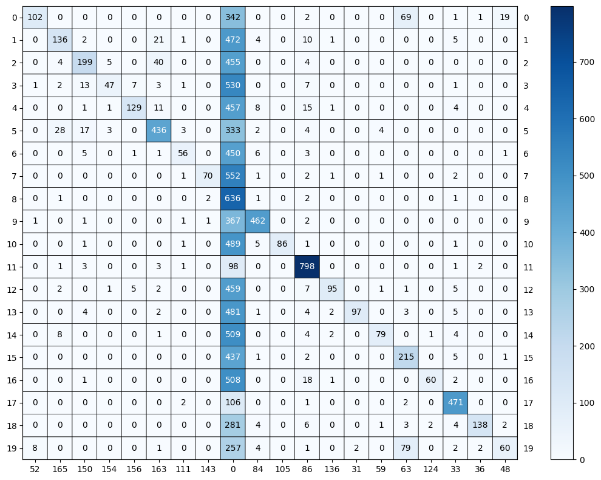

```python
umap_data = umap.UMAP(n_components=20, metric='euclidean').fit_transform(tfidf_preds)
scan = hdbscan.HDBSCAN(min_cluster_size = 20)
y_pred = scan.fit_predict(umap_data)

cm = contingency_matrix(data_full.target, y_pred)
rows, cols = linear_sum_assignment(cm, maximize=True)
reordered_mat = cm[np.ix_(rows, cols)]
plotmat.plot_mat(reordered_mat, xticklabels=cols, yticklabels=rows, size=(10,8))
```

QUESTION 17: Based on your experiments, which dimensionality reduction technique and clustering methods worked best together for 20-class text data and why? Follow the table below. If UMAP takes too long to converge, consider running it once and saving the intermediate results in a pickle file.

*Hint: DBSCAN and HDBSCAN do not accept the number of clusters as an input parameter. So pay close attention to how the different clustering metrics are being computed for these methods.*

```python
def compare_models(models_metrics):
    best_model = None
    best_score = -float('inf')
    for model, metrics in models_metrics.items():
        cumulative_score = np.sum(metrics)
        if cumulative_score > best_score:
            best_score = cumulative_score
            best_model = model

    return best_model, best_score
```

```python
# Takes 1 hour and 12 minutes to fully run
dimentionallity_reduction = [TruncatedSVD(n_components=5, random_state=42),
                             TruncatedSVD(n_components=20, random_state=42),
                             TruncatedSVD(n_components=200, random_state=42),
                             NMF(n_components=5, random_state=42),
                             NMF(n_components=20, random_state=42),
                             NMF(n_components=200, random_state=42),
                             umap.UMAP(n_components=5, metric='euclidean'),
                             umap.UMAP(n_components=20, metric='euclidean'),
                             umap.UMAP(n_components=200, metric='euclidean')]

cluster_techniques = [KMeans(n_clusters=10, random_state=42, max_iter=1000, n_init=30),
                      KMeans(n_clusters=20, random_state=42, max_iter=1000, n_init=30),
                      KMeans(n_clusters=50, random_state=42, max_iter=1000, n_init=30),
                      AgglomerativeClustering(n_clusters=20),
                      hdbscan.HDBSCAN(min_cluster_size=100),
                      hdbscan.HDBSCAN(min_cluster_size=200)]

model_metrics = {}
for i in dimentionallity_reduction:
    for c in cluster_techniques:
        if i is None:
            y_pred = c.fit_predict(tfidf_preds)
            hm_score = homogeneity_score(data_full.target, y_pred)
            comp_score = completeness_score(data_full.target, y_pred)
            v_score = v_measure_score(data_full.target, y_pred)
            rand_score = adjusted_rand_score(data_full.target, y_pred)
            mut_score = adjusted_mutual_info_score(data_full.target, y_pred)
            metrics_array = [hm_score, comp_score, v_score, rand_score, mut_score]
            model_metrics[f"{i},{c}"] = metrics_array
            print("Dimentionallity Reduction Type:", i, ", Clustering Type: ", c)
            print("Homogeneity : " , hm_score)
            print("Completeness : " , comp_score)
            print("V-measure : " , v_score)
            print("Adjusted Rand-Index : ", rand_score)
            print("Adjusted Mutual Information Score : ", mut_score)
        else:
            method = i.fit_transform(tfidf_preds)
            y_pred = c.fit_predict(method)
            hm_score = homogeneity_score(data_full.target, y_pred)
            comp_score = completeness_score(data_full.target, y_pred)
            v_score = v_measure_score(data_full.target, y_pred)
            rand_score = adjusted_rand_score(data_full.target, y_pred)
            mut_score = adjusted_mutual_info_score(data_full.target, y_pred)
            metrics_array = [hm_score, comp_score, v_score, rand_score, mut_score]
            model_metrics[f"{i},{c}"] = metrics_array
            print("Dimentionallity Reduction Type:", i, ", Clustering Type: ", c)
            print("Homogeneity : " , hm_score)
            print("Completeness : " , comp_score)
            print("V-measure : " , v_score)
            print("Adjusted Rand-Index : ", rand_score)
            print("Adjusted Mutual Information Score : ", mut_score)

best_model, best_score = compare_models(model_metrics)
print("Best Model Found is ", best_model)
print("With a score of ", best_score)
```

```
Dimentionallity Reduction Type: TruncatedSVD(n_components=5, random_state=42) , Clustering Type:  KMeans(max_iter=1000, n_clusters=10, n_init=30, random_state=42)
Homogeneity :  0.25273865828769104
Completeness :  0.3639992217811067
V-measure :  0.2983331425028029
Adjusted Rand-Index :  0.11262133015505373
Adjusted Mutual Information Score :  0.2970693666782106
Dimentionallity Reduction Type: TruncatedSVD(n_components=5, random_state=42) , Clustering Type:  KMeans(max_iter=1000, n_clusters=20, n_init=30, random_state=42)
Homogeneity :  0.3126207568897337
Completeness :  0.33144480930213405
V-measure :  0.32175769856430775
Adjusted Rand-Index :  0.12248763485114002
Adjusted Mutual Information Score :  0.3194995928145638
Dimentionallity Reduction Type: TruncatedSVD(n_components=5, random_state=42) , Clustering Type:  KMeans(max_iter=1000, n_clusters=50, n_init=30, random_state=42)
Homogeneity :  0.3617757672962524
Completeness :  0.29042847974142433
V-measure :  0.3221996378599729
Adjusted Rand-Index :  0.09263520495490955
Adjusted Mutual Information Score :  0.31708461648668484
Dimentionallity Reduction Type: TruncatedSVD(n_components=5, random_state=42) , Clustering Type:  AgglomerativeClustering(n_clusters=20)
Homogeneity :  0.30310687128330555
Completeness :  0.32738252149182245
V-measure :  0.31477735530316253
Adjusted Rand-Index :  0.12005558568374378
Adjusted Mutual Information Score :  0.3124748822850994
Dimentionallity Reduction Type: TruncatedSVD(n_components=5, random_state=42) , Clustering Type:  HDBSCAN(min_cluster_size=100)
Homogeneity :  0.0
Completeness :  1.0
V-measure :  0.0
Adjusted Rand-Index :  0.0
Adjusted Mutual Information Score :  0.0
Dimentionallity Reduction Type: TruncatedSVD(n_components=5, random_state=42) , Clustering Type:  HDBSCAN(min_cluster_size=200)
Homogeneity :  0.0
Completeness :  1.0
V-measure :  0.0
Adjusted Rand-Index :  0.0
Adjusted Mutual Information Score :  0.0
Dimentionallity Reduction Type: TruncatedSVD(n_components=20, random_state=42) , Clustering Type:  KMeans(max_iter=1000, n_clusters=10, n_init=30, random_state=42)
Homogeneity :  0.2761589150533012
Completeness :  0.43903515927729825
V-measure :  0.3390505531516107
```

[output cut: 271 more lines]

```
Adjusted Mutual Information Score :  0.5086687465481179
Dimentionallity Reduction Type: UMAP(n_components=200, tqdm_kwds={'bar_format': '{desc}: {percentage:3.0f}%| {bar} {n_fmt}/{total_fmt} [{elapsed}]', 'desc': 'Epochs completed', 'disable': True}) , Clustering Type:  HDBSCAN(min_cluster_size=100)
Homogeneity :  0.01394077175109458
Completeness :  0.4825762697636899
V-measure :  0.02709870988011164
Adjusted Rand-Index :  0.0006384068573917776
Adjusted Mutual Information Score :  0.026425332954461
Dimentionallity Reduction Type: UMAP(n_components=200, tqdm_kwds={'bar_format': '{desc}: {percentage:3.0f}%| {bar} {n_fmt}/{total_fmt} [{elapsed}]', 'desc': 'Epochs completed', 'disable': True}) , Clustering Type:  HDBSCAN(min_cluster_size=200)
Homogeneity :  0.013754781970847894
Completeness :  0.45727709920099674
V-measure :  0.026706246652025794
Adjusted Rand-Index :  0.0006068234788160461
Adjusted Mutual Information Score :  0.026039459057344345
Best Model Found is  UMAP(n_components=20, tqdm_kwds={'bar_format': '{desc}: {percentage:3.0f}%| {bar} {n_fmt}/{total_fmt} [{elapsed}]', 'desc': 'Epochs completed', 'disable': True}),KMeans(max_iter=1000, n_clusters=20, n_init=30, random_state=42)
With a score of  2.513408380968764
```

We can safely assume that without dimentionality reduction, we will have a suboptimal clustering result, furthermore, from our experiments, we can see that of the available techniques, a UMAP with 20 components and Kmeans and 20 clusters preforms best with the following metrics:

- Homogeneity : 0.5119337513721676
- Completeness : 0.5381320725495577
- V-measure : 0.5247060981474436
- Adjusted Rand-Index : 0.41551890463133057
- Adjusted Mutual Information Score : 0.5231175542682646

QUESTION 18: Extra credit: If you can find creative ways to further enhance the clustering performance, report your method and the results you obtain.

```
Homogeneity :  0.35324846286571226
Completeness :  0.6647802762512584
V-measure :  0.46134770405969555
Adjusted Rand-Index :  0.09668461226948066
Adjusted Mutual Information Score :  0.4589353981944944
```

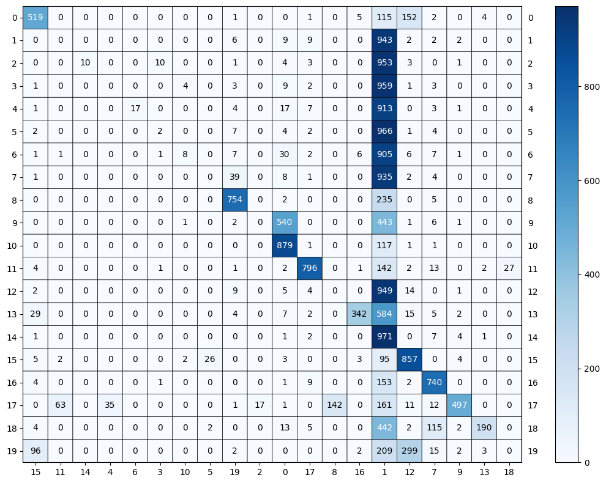

```python
from sklearn.cluster import SpectralClustering
spectral = SpectralClustering(n_clusters=20, affinity='nearest_neighbors')
y_pred = spectral.fit_predict(tfidf_preds)

cm = contingency_matrix(data_full.target, y_pred)

hm_score = homogeneity_score(data_full.target, y_pred)
comp_score = completeness_score(data_full.target, y_pred)
v_score = v_measure_score(data_full.target, y_pred)
rand_score = adjusted_rand_score(data_full.target, y_pred)
mut_score = adjusted_mutual_info_score(data_full.target, y_pred)

print("Homogeneity : " , hm_score)
print("Completeness : " , comp_score)
print("V-measure : " , v_score)
print("Adjusted Rand-Index : ", rand_score)
print("Adjusted Mutual Information Score : ", mut_score)

rows, cols = linear_sum_assignment(cm, maximize=True)
reordered_mat = cm[np.ix_(rows, cols)]
plotmat.plot_mat(reordered_mat, xticklabels=cols, yticklabels=rows, size=(10,8))
```

Unfortunatly, we were not able to get better results than our UMAP and KMeans implementation from part 17, however, some possible suggestions would be playing with UMAP hyperparameters like the number of neighbors, minimum distance from the center of the cluster, or attempting different embedding strategies to find the most optimal configuration.